# CS 501 HW 3

Author

Hayden Coke and Victoria Fox

Published

September 30, 2025

# Groupby Practice

We are going reuse the diamonds dataset from the previous homework in today’s exercise. For convenience the descriptions of each of the variables is copied here.

- **price:** price in US dollars ($326–$18,823)
- **carat:** weight of the diamond (0.2–5.01)
- **cut:** quality of the cut (Fair, Good, Very Good, Premium, Ideal)
- **color:** diamond colour, from J (worst) to D (best)
- **clarity:** a measurement of how clear the diamond is (I1 (worst), SI2, SI1, VS2, VS1, VVS2, VVS1, IF (best))
- **x:** length in mm (0–10.74)
- **y:** width in mm (0–58.9)
- **z:** depth in mm (0–31.8)
- **depth:** total depth percentage = z / mean(x, y) = 2 * z / (x + y) (43–79)
- **table:** width of top of diamond relative to widest point (43–95)

The goal of the exercise is to re-implement some of our previous analyses using the groupby method.

## Instructions

Use the categorical variables in the dataset (cut, color, and clarity) to group and summarize the numeric variables (price, carat, x, y, z, depth, and table). Create the following outputs:

1. A Series showing the average price by clarity
2. A DataFrame showing the average x, y, and z by cut
3. A DataFrame showing the average of all the numeric variables by color
4. A DataFrame that includes the min, max, mean, and median price by clarity
5. A DataFrame showing how many diamonds of each clarity there are for each cut (Hint: you can use the `count` function)
6. A DataFrame grouped by cut, which shows the median for both depth and table, the mean and median for carat, and the count for clarity (provide names for each of the output variables, like “median_depth”)
7. A Dataframe grouped by cut, which shows how many diamonds there are of each color and clarity

Lastly, use your newly created data structure to generate an appropriate plot for question #7.

## Extra Credit

Use `pd.cut()` to create a new variable in the dataframe called `price_binned` that bins the price variable into three levels: ‘cheap’ (less than the 25th quantile), ‘moderate’ (between the 25th quantile and the 75th quantile), and ‘expensive’ (greater than the 75th quantile). Use `groupby` to calculate the mean price for each price category to roughly check your work.

Then use this variable to create a new dataframe with a multi-index (group by two variables: `price_binned` and `clarity`), with output columns named `mean_carat`, `median_carat`, and `count`.

Use multi-index indexing to print only the `count` column for each `clarity` level in the `cheap` category.

## Answers

Your text and code goes here! Use markdown to nicely format your plots and answers.

```python
# import libraries
import numpy as np
import pandas as pd
import matplotlib as mpl
import matplotlib.pyplot as plt
import seaborn as sns

# import dataset
df = pd.read_csv('./../../datasets/diamonds.csv')
df
```

|  | carat | cut | color | clarity | depth | table | price | x | y | z |
| --- | --- | --- | --- | --- | --- | --- | --- | --- | --- | --- |
| 0 | 0.23 | Ideal | E | SI2 | 61.5 | 55.0 | 326 | 3.95 | 3.98 | 2.43 |
| 1 | 0.21 | Premium | E | SI1 | 59.8 | 61.0 | 326 | 3.89 | 3.84 | 2.31 |
| 2 | 0.23 | Good | E | VS1 | 56.9 | 65.0 | 327 | 4.05 | 4.07 | 2.31 |
| 3 | 0.29 | Premium | I | VS2 | 62.4 | 58.0 | 334 | 4.20 | 4.23 | 2.63 |
| 4 | 0.31 | Good | J | SI2 | 63.3 | 58.0 | 335 | 4.34 | 4.35 | 2.75 |
| ... | ... | ... | ... | ... | ... | ... | ... | ... | ... | ... |
| 53935 | 0.72 | Ideal | D | SI1 | 60.8 | 57.0 | 2757 | 5.75 | 5.76 | 3.50 |
| 53936 | 0.72 | Good | D | SI1 | 63.1 | 55.0 | 2757 | 5.69 | 5.75 | 3.61 |
| 53937 | 0.70 | Very Good | D | SI1 | 62.8 | 60.0 | 2757 | 5.66 | 5.68 | 3.56 |
| 53938 | 0.86 | Premium | H | SI2 | 61.0 | 58.0 | 2757 | 6.15 | 6.12 | 3.74 |
| 53939 | 0.75 | Ideal | D | SI2 | 62.2 | 55.0 | 2757 | 5.83 | 5.87 | 3.64 |

53940 rows × 10 columns

1. A Series showing the average price by clarity

```python
clarity_avg = df.groupby('clarity')['price'].mean()

clarity_avg
```

```
clarity
I1      3924.168691
IF      2864.839106
SI1     3996.001148
SI2     5063.028606
VS1     3839.455391
VS2     3924.989395
VVS1    2523.114637
VVS2    3283.737071
Name: price, dtype: float64
```

2. A DataFrame showing the average x, y, and z by cut

```python
xyz_avg = df.groupby('cut')[['x','y','z']].mean()

xyz_avg
```

| cut | x | y | z |
| --- | --- | --- | --- |
| Fair | 6.246894 | 6.182652 | 3.982770 |
| Good | 5.838785 | 5.850744 | 3.639507 |
| Ideal | 5.507451 | 5.520080 | 3.401448 |
| Premium | 5.973887 | 5.944879 | 3.647124 |
| Very Good | 5.740696 | 5.770026 | 3.559801 |

3. A DataFrame showing the average of all the numeric variables by color

```python
numerics_avg = df.groupby('color')[['carat','depth','table','price','x','y','z']].mean()

numerics_avg
```

| color | carat | depth | table | price | x | y | z |
| --- | --- | --- | --- | --- | --- | --- | --- |
| D | 0.657795 | 61.698125 | 57.404590 | 3169.954096 | 5.417051 | 5.421128 | 3.342827 |
| E | 0.657867 | 61.662090 | 57.491201 | 3076.752475 | 5.411580 | 5.419029 | 3.340689 |
| F | 0.736538 | 61.694582 | 57.433536 | 3724.886397 | 5.614961 | 5.619456 | 3.464446 |
| G | 0.771190 | 61.757111 | 57.288629 | 3999.135671 | 5.677543 | 5.680192 | 3.505021 |
| H | 0.911799 | 61.836850 | 57.517811 | 4486.669196 | 5.983335 | 5.984815 | 3.695965 |
| I | 1.026927 | 61.846385 | 57.577278 | 5091.874954 | 6.222826 | 6.222730 | 3.845411 |
| J | 1.162137 | 61.887215 | 57.812393 | 5323.818020 | 6.519338 | 6.518105 | 4.033251 |

4. A DataFrame that includes the min, max, mean, and median price by clarity

```python
clarity_prices = df.groupby('clarity')['price'].agg(['mean','min','max','median'])

clarity_prices
```

| clarity | mean | min | max | median |
| --- | --- | --- | --- | --- |
| I1 | 3924.168691 | 345 | 18531 | 3344.0 |
| IF | 2864.839106 | 369 | 18806 | 1080.0 |
| SI1 | 3996.001148 | 326 | 18818 | 2822.0 |
| SI2 | 5063.028606 | 326 | 18804 | 4072.0 |
| VS1 | 3839.455391 | 327 | 18795 | 2005.0 |
| VS2 | 3924.989395 | 334 | 18823 | 2054.0 |
| VVS1 | 2523.114637 | 336 | 18777 | 1093.0 |
| VVS2 | 3283.737071 | 336 | 18768 | 1311.0 |

5. A DataFrame showing how many diamonds of each clarity there are for each cut (Hint: you can use the `count` function)

```python
clarity_cut_count = df.groupby(['cut', 'clarity'])['price'].count()

clarity_cut_count
```

```
cut        clarity
Fair       I1          210
           IF            9
           SI1         408
           SI2         466
           VS1         170
           VS2         261
           VVS1         17
           VVS2         69
Good       I1           96
           IF           71
           SI1        1560
           SI2        1081
           VS1         648
           VS2         978
           VVS1        186
           VVS2        286
Ideal      I1          146
           IF         1212
           SI1        4282
           SI2        2598
           VS1        3589
           VS2        5071
           VVS1       2047
           VVS2       2606
Premium    I1          205
           IF          230
           SI1        3575
           SI2        2949
           VS1        1989
           VS2        3357
           VVS1        616
           VVS2        870
Very Good  I1           84
           IF          268
           SI1        3240
           SI2        2100
           VS1        1775
           VS2        2591
           VVS1        789
           VVS2       1235
Name: price, dtype: int64
```

6. A DataFrame grouped by cut, which shows the median for both depth and table, the mean and median for carat, and the count for clarity (provide names for each of the output variables, like “median_depth”)

```python
cut_stats = df.groupby('cut').agg(
    depth_median = ('depth', 'median'),
    table_median = ('table', 'median'),
    carat_mean   = ('carat', 'mean'),
    carat_median = ('carat', 'median'),
    clarity_count = ('clarity', 'count')
)

cut_stats
```

| cut | depth_median | table_median | carat_mean | carat_median | clarity_count |
| --- | --- | --- | --- | --- | --- |
| Fair | 65.0 | 58.0 | 1.046137 | 1.00 | 1610 |
| Good | 63.4 | 58.0 | 0.849185 | 0.82 | 4906 |
| Ideal | 61.8 | 56.0 | 0.702837 | 0.54 | 21551 |
| Premium | 61.4 | 59.0 | 0.891955 | 0.86 | 13791 |
| Very Good | 62.1 | 58.0 | 0.806381 | 0.71 | 12082 |

7. A Dataframe grouped by cut, which shows how many diamonds there are of each color and clarity

```python
ccc = df.groupby(['cut', 'color', 'clarity'])['price'].count()
ccc
```

```
cut        color  clarity
Fair       D      I1           4
                  IF           3
                  SI1         58
                  SI2         56
                  VS1          5
                            ...
Very Good  J      SI2        128
                  VS1        120
                  VS2        184
                  VVS1        19
                  VVS2        29
Name: price, Length: 276, dtype: int64
```

Plot:

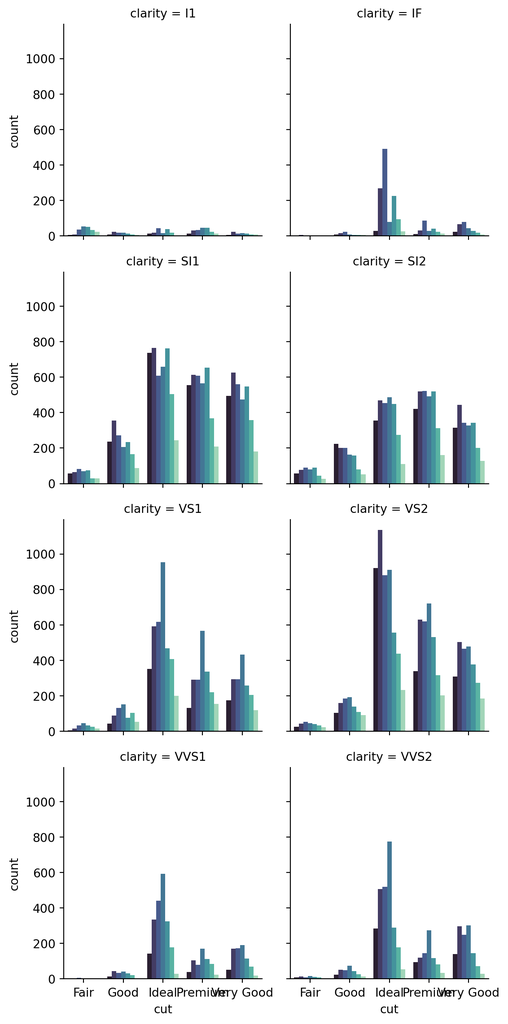

```python
ccc_reset_index = ccc.reset_index(name="count")

g = sns.FacetGrid(ccc_reset_index, col="clarity", col_wrap=2)
g.map_dataframe(sns.barplot, x="cut", y="count", hue="color", palette="mako")

plt.show()
```